# DeepInsight Visible Neural Network: Quick Start divnn python

Herdiantri Sufriyana, Yu-Wei Wu and Emily Chia-Yu Su

Graduate Institute of Biomedical Informatics, College of Medical Science and Technology, Taipei Medical University, Taipei, Taiwan  
Department of Medical Physiology, College of Medicine, University of Nahdlatul Ulama Surabaya, Surabaya, Indonesia  
Clinical Big Data Research Center, Taipei Medical University Hospital, Taipei, Taiwan  
Research Center for Artificial Intelligence in Medicine, Taipei Medical University, Taipei, Taiwan

herdiantrisufriyana@unusa.ac.id

21 November 2020

#### Abstract

This vignette explains how to use this module using simulated data. However, reader may need to read another vignette to apply the DeepInsight Visible Neural Network (DI-VNN) model based on the original works of DeepInsight and VNN from Alok Sharma and Michael Ku Yu, respectively.

#### Package

divnn 0.1.1

# 1 Install and import

You can install this module using pip install git+. Then import this module as shown below.

```python
import os
os.system('pip install git+https://github.com/herdiantrisufriyana/divnn')

from divnn import utils, TidySet, generator
from divnn.ExpressionSet import exprs, notes
```

Several modules are needed to load explicitly since training and the other functions are not included in this module. For simplicity, code to turn off your GPU is also provided below.

```python
import os
import pickle
import pandas as pd
import numpy as np
import regex as re
import math
os.environ['CUDA_VISIBLE_DEVICES']='-1'
from tensorflow import keras
from tensorflow.keras.models import model_from_json
```

# 2 Load simulated data

Load simulated data using this code.

```python
input=utils.example()
```

The first input is a instance-feature value pandas data frame with rows for instances and columns for features. All rows in value should have names. All values should be floating numbers.

Table 1: Summary of instance-feature value data frame

| attribute | outcome_0 | outcome_1 |
| --- | --- | --- |
| F1 | 0.13 ± 0.97 | -0.04 ± 1.05 |
| F2 | -0.8 ± 0.68 | 0.78 ± 0.65 |
| F3 | 0.05 ± 0.99 | -0.03 ± 0.99 |
| F4 | 0.08 ± 0.98 | -0.05 ± 1 |
| F5 | 0.27 ± 0.96 | -0.25 ± 0.97 |
| outcome | 1502 | 1498 |

The second input is and outcome binary integers as a single-column pandas data frame with the same rows as the instances. The row numbers, the names, and the order of outcome should be the same with those of value. Value of 0 and 1 should refer to non-event and event outcome, respectively.

```
##        outcome
## I1           1
## I2           1
## I3           1
## I4           1
## I5           1
## ...        ...
## I2996        1
## I2997        0
## I2998        1
## I2999        0
## I3000        0
##
## [3000 rows x 1 columns]
```

The third input is a similarity pandas data frame of floating numbers containing feature-feature similarity measures.

Table 2: Feature similarity matrix

|  | F1 | F2 | F3 | F4 | F5 |
| --- | --- | --- | --- | --- | --- |
| F1 | 1.0000000 | 0.5256045 | 0.8660282 | 0.4867348 | 0.8448117 |
| F2 | 0.5256045 | 1.0000000 | 0.0584934 | -0.2578459 | 0.0352451 |
| F3 | 0.8660282 | 0.0584934 | 1.0000000 | 0.8045942 | 0.9485934 |
| F4 | 0.4867348 | -0.2578459 | 0.8045942 | 1.0000000 | 0.7456460 |
| F5 | 0.8448117 | 0.0352451 | 0.9485934 | 0.7456460 | 1.0000000 |

The fourth input is a feature three-dimensional pandas data frame of floating numbers with rows for features and three columns for three dimensions where the features are mapped onto.

Table 3: Feature three-dimensional mapping matrix

|  | dimension1 | dimension2 | dimension3 |
| --- | --- | --- | --- |
| F1 | 0.0416189 | -0.4044777 | -0.0506486 |
| F2 | 1.4638855 | 0.1294247 | 0.0115047 |
| F3 | -0.4837955 | -0.1100427 | -0.0095783 |
| F4 | -0.5606794 | 0.4849659 | -0.0310572 |
| F5 | -0.4610294 | -0.0998703 | 0.0797794 |

The fifth input is an ontology pandas data frame with rows for ontologies and four columns for source, target, similarity, and relation. Feature (source)- ontology (target) relation should be annotated as ‘feature’, while ontology- ontology relation should be annotated as ‘is_a’. To differentiate between feature and ontology names, a prefix of ‘ONT:’ precedes an ontology name. All columns except similarity in ontology should be characters. Similarity (a numeric) is a minimum threshold by which either features or ontologies (source) belong to an ontology (target).

Table 4: Ontology data frame

|  | source | target | similarity | relation |
| --- | --- | --- | --- | --- |
| 0 | F3 | ONT:1 | 0.9742967 | feature |
| 4 | F1 | ONT:1 | 0.9742967 | feature |
| 1 | F2 | ONT:2 | 0.9224059 | feature |
| 5 | ONT:1 | ONT:2 | 0.9224059 | is_a |
| 2 | F5 | ONT:3 | 0.7433674 | feature |
| 6 | ONT:2 | ONT:3 | 0.7433674 | is_a |
| 3 | F4 | ONT:4 | 0.3710771 | feature |
| 7 | ONT:3 | ONT:4 | 0.3710771 | is_a |

In addition, a result of hierarchical clustering is also shown below for visualization to get intuition how the features are grouped and how the connection constructs the VNN model architecture.

Table 5: Ontology data frame

| label | feature |
| --- | --- |
| 3 | F4 |
| 4 | F5 |
| 1 | F2 |
| 2 | F3 |
| 0 | F1 |

# 3 Create TidySet

Create a TidySet using this code.

```r
tidy_set=TidySet.compile(
    value=input['value']
    ,outcome=input['outcome']
    ,similarity=input['similarity']
    ,mapping=input['mapping']
    ,ontology=input['ontology']
  )
```

TidySet is an ExpressionSet with three tables. Instance-feature value and outcome pandas data frame are compiled as a phenotype pandas data frame with rows for instances and columns for features and outcome.

```python
tidy_set.desc()
```

```
## ExpressionSet (storageMode: lockedEnvironment)
## assayData: 49 features, 3000 samples
##   element names: exprs
## protocolData: none
## phenoData
##   sampleNames: I1 I2 ... I3000 (3000 total)
##   varLabels: outcome F4 F3 ... F1
##   varMetadata: labelDescription
## featureData
##   featureNames: x1y1z1 x2y1z1 ... x7y7z1 (49 total)
##   fvarLabels: feature ONT1 ONT2 ... ONT4
##   fvarMetadata: labelDescription
## experimentData: use ".experimentData.desc()"
## Annotation:
```

Instance-feature value and feature three-dimensional mapping pandas data frame are compiled as an expression two-dimensional array with rows for positions of features and columns for instances. The mapping, similarity, and ontology pandas data frame are compiled as a feature pandas data frame with rows for positions of features and columns for feature names and ontological relations. For easier access, the similarity pandas data frame, ontomap four-dimensional numpy array, ontotype dictionary of pandas data frame, and ontology pandas data frame are included in experiment notes that can be called using function of notes.

Table 6: Dimensions of three tables

|  | dimension 1 | dimension 2 |
| --- | --- | --- |
| Phenotype data frame | 3000 | 6 |
| Feature data frame | 49 | 5 |
| Expression matrix | 49 | 3000 |

Recall experiment notes such similarity, ontomap, ontotype, and ontology using this code.

```python
# Recall a similarity matrix
notes(tidy_set.experimentData)['similarity']

# Recall an ontomap four-dimensional array
notes(tidy_set.experimentData)['ontomap']

# Recall an ontotype list of two-dimensional matrices
notes(tidy_set.experimentData)['ontotype']

# Recall an ontology data frame
notes(tidy_set.experimentData)['ontology']
```

# 4 Save or load a TidySet

Use this code to save a TidySet by writing a .ts.tar.gz file containing exprs.csv, pData.csv, fData.csv, similarity.csv, ontology.csv, and others.txt.

```python
TidySet.write(tidy_set,'quick-start-py/tidy_set_py')
```

Function of TidySet.read can read this file back to a TidySet. Use this code to load a TidySet by reading a .ts.tar.gz file.

```python
tidy_set=TidySet.read('quick-start-py/tidy_set_py.ts.tar.gz')
```

# 5 Create ontonet

Let’s create a function that generate a Keras Convolutional Neural Network (CNN) model with a specific layer architecture for each path in the hierarchy of the given ontology. The model architecture can be saved to JSON for later use by specifying the file path; otherwise (by let it NULL), no JSON will be created.

```python
ontonet=generator.ontonet(tidy_set,path='quick-start-py/ontonet_py')
```

# 6 Set up hyperparameters

The model is compiled with stochastic gradient decent (SGD) using learning rate (LR) of 2^-6 and momentum of 0.9. The loss function is mean squared error (MSE) with weight of 1 for main output and 0.3 fir auxiliary output. The evaluation metric is accuracy.

The LR will be reduced by factor of 0.1 at iteration 30, 60, and 80 (but with 0-based index). Early stopping will also happen if validation loss does not decrease >0.001 after 30 iterations. The best weight at minimum validation loss will be applied.

```python
ontonet.compile(
    optimizer=keras.optimizers.SGD(
      learning_rate=2**-6
      ,momentum=0.9
    )
    ,loss='mean_squared_error'
    ,loss_weights=np.repeat(0.3,len(ontonet.outputs)-1).tolist()+[1]
    ,metrics=['accuracy']
  )

def cb_lr_reduction(epoch,lr):
  lr_factor=0.1
  if epoch in [29,59,79]: lr=lr*lr_factor
  return lr
cb_lr_reduction=keras.callbacks.LearningRateScheduler(cb_lr_reduction)

cb_early_stopping=keras.callbacks.EarlyStopping(
    monitor='val_loss'
    ,mode='min'
    ,min_delta=0.001
    ,patience=30
    ,restore_best_weights=True
  )
```

# 7 Data partition

We hold out ~20% dataset for test set, while ~20% of the remaining will be a validation set. Training set will use the 80% of the remaining instances.

# 8 Model training

We use this code to train the model. The sample generator for ontoarray will take 32 samples for each batch. This step is repeated until all samples of training set are used per epoch, up to 100 epochs, but can be stopped earlier. For each epoch, validation performance is also measured with the same batch size.

```python
history=ontonet.fit_generator(
    generator=generator.ontoarray(
        tidy_set
        ,[index[i] for i in train_i]
        ,batch_size=32
      )
    ,steps_per_epoch=math.ceil(len(train_i)/32)
    ,validation_data=generator.ontoarray(
        tidy_set
        ,[index[i] for i in val_i]
        ,batch_size=32
      )
    ,validation_steps=math.ceil(len(val_i)/32)
    ,epochs=100
    ,callbacks=[cb_lr_reduction,cb_early_stopping]
    ,verbose=1
  )
```

Here below is the training result. We can estimate the iteration of which the weights are optimum for prediction.

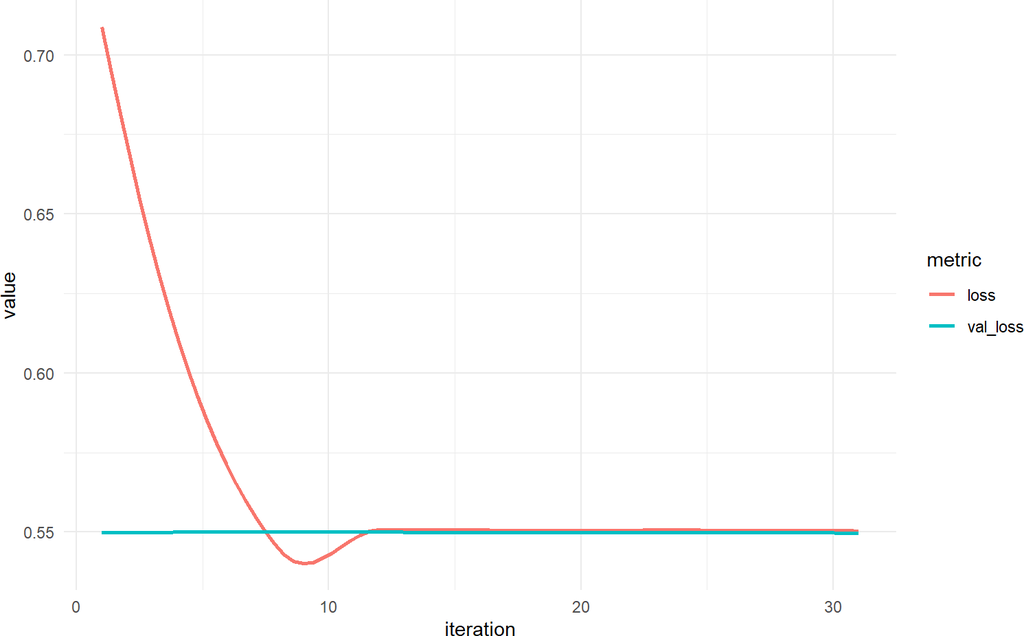

Figure 1: Plot training and validation losses

# 9 Model evaluation

```python
np.random.seed(33)
evaluation={}
for i in np.arange(30):
  test_i_boot=np.random.choice(
    test_i
    ,size=len(test_i)
    ,replace=True
  ).tolist()
  evaluation[i]=ontonet.evaluate_generator(
    generator=generator.ontoarray(
        tidy_set
        ,[index[i] for i in test_i_boot]
        ,batch_size=32
      )
    ,steps=math.ceil(len(test_i)/32)
  )
```

The point and interval (95% CI) estimates of accuracy can be computed by the bootstrapping.

| metric | mean | lb | ub |
| --- | --- | --- | --- |
| root_accuracy | 0.8891996 | 0.8840182 | 0.8943809 |

# 10 Session info

```python
from sinfo import sinfo
sinfo()
```

```
## -----
## divnn               NA
## matplotlib          3.1.0
## numpy               1.18.5
## pandas              1.0.5
## regex               2.5.91
## scipy               1.5.0
## sinfo               0.3.1
## tensorflow          2.0.0
## tensorflow_core     2.0.0
## -----
## Python 3.6.3 |Anaconda, Inc.| (default, Nov  8 2017, 15:10:56) [MSC v.1900 64 bit (AMD64)]
## Windows-10-10.0.18362-SP0
## 8 logical CPU cores, Intel64 Family 6 Model 60 Stepping 3, GenuineIntel
## -----
## Session information updated at 2020-11-21 21:16
```